# 這份檔案會講解以下幾個部分:

- X-ray image normalization
- 如何把 mask image 轉為 bounding box
- 如何把資料集轉換為 COCO format
- 如何將資料存為 .jpg & .json

# Rename files & Save .csv as UTF-8 encoding format

1. 上傳資料前先將資料夾名稱換成英文:
- normal -> normal
- 心臟肥大 -> cardiac_hypertrophy
- 主動脈硬鈣化 -> aortic_atherosclerosis_calcification
- 主動脈彎曲 -> aortic_curvature
- 肺尖肋膜增厚 -> intercostal_pleural_thickening
- 肺野浸潤增加 -> lung_field_infiltration
- 胸椎退化性關節病變 -> degenerative_joint_disease_of_the_thoracic_spine
- 脊椎側彎 -> scoliosis
1. 另外，要先在自己的電腦用記事本打開 csv 檔，並另存為 utf-8 編碼再上傳，不然打開會出現亂碼！

# Check data & images

```python
!pip install pydicom
```

```python
!pip install scikit-multilearn
```

```python
# import libraries

# basic
import warnings
warnings.filterwarnings('ignore')

import os
import random
import pydicom
import itertools
import numpy as np
import pandas as pd
from sklearn.preprocessing import MultiLabelBinarizer
from skmultilearn.model_selection import iterative_train_test_split

# visualization
from PIL import Image
import matplotlib.pyplot as plt
import matplotlib.patches as patches
import matplotlib.gridspec as gridspec

# object detection
import json
from skimage.measure import label as sk_label
from skimage.measure import regionprops as sk_regions
```

```python
from google.colab import drive
drive.mount('/content/drive')

data_path = '/content/drive/My Drive/hwk05_data'
print("目錄內容：", os.listdir(data_path))  # 檢查檔案是否存在
```

```
目錄內容： ['README.pdf', 'train.csv', 'test.csv', 'test', 'train', 'val.json', 'train.json']
```

```python
class config:
    root = "/content/drive/MyDrive/hwk05_data"
    #root = "/kaggle/input/dlmia-hw05-2/hwk05-csv-utf8" ## your own base root path
    seed = 42
```

```python
def seed_everything(seed):
    # Set Python random seed
    random.seed(seed)

    # Set NumPy random seed
    np.random.seed(seed)

seed_everything(config.seed)
```

```python
# training dataframe
#train_df = pd.read_csv("/kaggle/input/dlmia-hw05-2/hwk05-csv-utf8/train.csv")
train_df = pd.read_csv("/content/drive/MyDrive/hwk05_data/train.csv")
train_df
```

|  | ID | category | Width | Height | Filename | ImagePath | MarkPath |
| --- | --- | --- | --- | --- | --- | --- | --- |
| 0 | TDR04_20180315_075734 | normal | 2328 | 2344 | 220_97.dcm | /normal/image/220_97.dcm | /normal/mark/220_97.dcm.jpg |
| 1 | TDR04_20180315_080518 | normal | 2472 | 2560 | 220_94.dcm | /normal/image/220_94.dcm | /normal/mark/220_94.dcm.jpg |
| 2 | TDR04_20180315_081322 | normal | 2312 | 2496 | 220_93.dcm | /normal/image/220_93.dcm | /normal/mark/220_93.dcm.jpg |
| 3 | TDR04_20180315_081746 | normal | 2448 | 2584 | 220_92.dcm | /normal/image/220_92.dcm | /normal/mark/220_92.dcm.jpg |
| 4 | TDR04_20180315_082113 | normal | 2144 | 2384 | 220_91.dcm | /normal/image/220_91.dcm | /normal/mark/220_91.dcm.jpg |
| ... | ... | ... | ... | ... | ... | ... | ... |
| 446 | TDR02_20161209_161439 | հ s | 2376 | 2592 | 4440_5.dcm | / հ s/image/4440_5.dcm | / հ s/mark/4440_5.dcm.jpg |
| 447 | TDR04_20180224_084933 | հ s | 2248 | 2600 | 4440_0.dcm | / հ s/image/4440_0.dcm | / հ s/mark/4440_0.dcm.jpg |
| 448 | TDR04_20180226_082354 | հ s | 2488 | 2456 | 4440.dcm | / հ s/image/4440.dcm | / հ s/mark/4440.dcm.jpg |
| 449 | TDR01_20171106_095308 | հ s | 2320 | 2376 | A0_29.dcm | / հ s/image/A0_29.dcm | / հ s/mark/A0_29.dcm.jpg |
| 450 | TDR01_20171108_100516 | հ s | 2280 | 2288 | A0_28.dcm | / հ s/image/A0_28.dcm | / հ s/mark/A0_28.dcm.jpg |

451 rows × 7 columns

```python
# 假設您想根據 "label" 欄位分組
grouped = train_df.groupby("category")
for name, group in grouped:
    print(f"Group: {name}, Size: {len(group)}")
```

```
Group:   Ŧ Τj, Size: 33
Group:   հ  s, Size: 58
Group:  D ʯ  s  , Size: 52
Group:  D ʯߵw t  , Size: 71
Group:  ͦy ؽ  W p, Size: 29
Group:  ͳ     W [, Size: 68
Group:  ݴհh Ʃ    ` f  , Size: 60
Group: normal, Size: 80
```

## 更改類別名稱為英文

```python
#因為可能因為我的電腦的關係，所以我資料一下載下來就亂碼，我修正更改類別的方式
# 用來存放每個分組的大小和其對應的英文名稱的字典
size_to_category = {
    33: "cardiac_hypertrophy",
    58: "scoliosis",
    52: "aortic_curvature",
    71: "aortic_atherosclerosis_calcification",
    29: "intercostal_pleural_thickening",
    68: "lung_field_infiltration",
    60: "degenerative_joint_disease_of_the_thoracic_spine",
    80: "normal"
}

# 重新設置 group 的名稱，使用 size 來對應 category 名稱
def change_to_eng_names_by_size(df):
    grouped = df.groupby("category")
    for name, group in grouped:
        # 根據大小來對應英文名稱
        group_size = len(group)
        if group_size in size_to_category:
            new_category = size_to_category[group_size]
            # 更新 category 欄位
            df.loc[group.index, "category"] = new_category
            # 更新 ImagePath 和 MarkPath
            df.loc[group.index, "ImagePath"] = df.loc[group.index].apply(lambda x: f"{new_category}/image/{x['Filename']}", axis=1)
            df.loc[group.index, "MarkPath"] = df.loc[group.index].apply(lambda x: f"{new_category}/mark/{x['Filename']}.jpg", axis=1)
    return df

# 呼叫函數並更新 train_df
train_df = change_to_eng_names_by_size(train_df)

# 顯示更新後的 train_df
train_df
```

|  | ID | category | Width | Height | Filename | ImagePath | MarkPath |
| --- | --- | --- | --- | --- | --- | --- | --- |
| 0 | TDR04_20180315_075734 | normal | 2328 | 2344 | 220_97.dcm | normal/image/220_97.dcm | normal/mark/220_97.dcm.jpg |
| 1 | TDR04_20180315_080518 | normal | 2472 | 2560 | 220_94.dcm | normal/image/220_94.dcm | normal/mark/220_94.dcm.jpg |
| 2 | TDR04_20180315_081322 | normal | 2312 | 2496 | 220_93.dcm | normal/image/220_93.dcm | normal/mark/220_93.dcm.jpg |
| 3 | TDR04_20180315_081746 | normal | 2448 | 2584 | 220_92.dcm | normal/image/220_92.dcm | normal/mark/220_92.dcm.jpg |
| 4 | TDR04_20180315_082113 | normal | 2144 | 2384 | 220_91.dcm | normal/image/220_91.dcm | normal/mark/220_91.dcm.jpg |
| ... | ... | ... | ... | ... | ... | ... | ... |
| 446 | TDR02_20161209_161439 | scoliosis | 2376 | 2592 | 4440_5.dcm | scoliosis/image/4440_5.dcm | scoliosis/mark/4440_5.dcm.jpg |
| 447 | TDR04_20180224_084933 | scoliosis | 2248 | 2600 | 4440_0.dcm | scoliosis/image/4440_0.dcm | scoliosis/mark/4440_0.dcm.jpg |
| 448 | TDR04_20180226_082354 | scoliosis | 2488 | 2456 | 4440.dcm | scoliosis/image/4440.dcm | scoliosis/mark/4440.dcm.jpg |
| 449 | TDR01_20171106_095308 | scoliosis | 2320 | 2376 | A0_29.dcm | scoliosis/image/A0_29.dcm | scoliosis/mark/A0_29.dcm.jpg |
| 450 | TDR01_20171108_100516 | scoliosis | 2280 | 2288 | A0_28.dcm | scoliosis/image/A0_28.dcm | scoliosis/mark/A0_28.dcm.jpg |

451 rows × 7 columns

```python
# 確認更新後的分組結果
grouped_after_update = train_df.groupby("category")
for name, group in grouped_after_update:
    print(f"Group: {name}, Size: {len(group)}")
```

```
Group: aortic_atherosclerosis_calcification, Size: 71
Group: aortic_curvature, Size: 52
Group: cardiac_hypertrophy, Size: 33
Group: degenerative_joint_disease_of_the_thoracic_spine, Size: 60
Group: intercostal_pleural_thickening, Size: 29
Group: lung_field_infiltration, Size: 68
Group: normal, Size: 80
Group: scoliosis, Size: 58
```

```python
#助教code
"""
# all classes
category = {
    "心臟肥大": "cardiac_hypertrophy",
    "主動脈硬鈣化": "aortic_atherosclerosis_calcification",
    "主動脈彎曲": "aortic_curvature",
    "肺尖肋膜增厚": "intercostal_pleural_thickening",
    "肺野浸潤增加": "lung_field_infiltration",
    "胸椎退化性關節病變": "degenerative_joint_disease_of_the_thoracic_spine",
    "脊椎側彎": "scoliosis",
    "normal": "normal"
}
"""
```

```
'\n# all classes\ncategory = {\n    "心臟肥大": "cardiac_hypertrophy",\n    "主動脈硬鈣化": "aortic_atherosclerosis_calcification",\n    "主動脈彎曲": "aortic_curvature",\n    "肺尖肋膜增厚": "intercostal_pleural_thickening",\n    "肺野浸潤增加": "lung_field_infiltration",\n    "胸椎退化性關節病變": "degenerative_joint_disease_of_the_…
```

```python
"""
# change category names to English
def change_to_eng_names(df):

    df["category"] = df["category"].apply(lambda x: category[x])
    df["ImagePath"] = df.apply(lambda df: "/".join([df["category"], "image", df["Filename"]]), axis=1)
    df["MarkPath"] = df.apply(lambda df: "/".join([df["category"], "mark", df["Filename"] + ".jpg"]), axis=1)

change_to_eng_names(train_df)
train_df
"""
```

```
'\n# change category names to English\ndef change_to_eng_names(df):\n\n    df["category"] = df["category"].apply(lambda x: category[x])\n    df["ImagePath"] = df.apply(lambda df: "/".join([df["category"], "image", df["Filename"]]), axis=1)\n    df["MarkPath"] = df.apply(lambda df: "/".join([df["cate…
```

## 畫出8種類別的第一張 image & mask 位置

這裡如果類別是 normal，就自行生成一個 shape 和原始影像相同的 mask。

```python
temp = train_df[train_df["category"].duplicated() == False]
temp
```

|  | ID | category | Width | Height | Filename | ImagePath | MarkPath |
| --- | --- | --- | --- | --- | --- | --- | --- |
| 0 | TDR04_20180315_075734 | normal | 2328 | 2344 | 220_97.dcm | normal/image/220_97.dcm | normal/mark/220_97.dcm.jpg |
| 80 | TDR04_20180227_083423 | aortic_curvature | 2504 | 2536 | 220_14.dcm | aortic_curvature/image/220_14.dcm | aortic_curvature/mark/220_14.dcm.jpg |
| 132 | TDR01_20190313_090724 | aortic_atherosclerosis_calcification | 2392 | 2600 | 10_1d.dcm | aortic_atherosclerosis_calcification/image/10_... | aortic_atherosclerosis_calcification/mark/10_1... |
| 203 | TDR04_20180226_090403 | cardiac_hypertrophy | 2008 | 2280 | 4440.dcm | cardiac_hypertrophy/image/4440.dcm | cardiac_hypertrophy/mark/4440.dcm.jpg |
| 236 | TDR05_20151105_094209 | intercostal_pleural_thickening | 2296 | 2512 | 4440_4.dcm | intercostal_pleural_thickening/image/4440_4.dcm | intercostal_pleural_thickening/mark/4440_4.dcm... |
| 265 | TDR04_20180227_083423 | lung_field_infiltration | 2504 | 2536 | 220_3.dcm | lung_field_infiltration/image/220_3.dcm | lung_field_infiltration/mark/220_3.dcm.jpg |
| 333 | TDR04_20180227_085056 | degenerative_joint_disease_of_the_thoracic_spine | 2336 | 2360 | 220_15.dcm | degenerative_joint_disease_of_the_thoracic_spi... | degenerative_joint_disease_of_the_thoracic_spi... |
| 393 | TDR01_20171109_083459 | scoliosis | 2232 | 2408 | A0_26.dcm | scoliosis/image/A0_26.dcm | scoliosis/mark/A0_26.dcm.jpg |

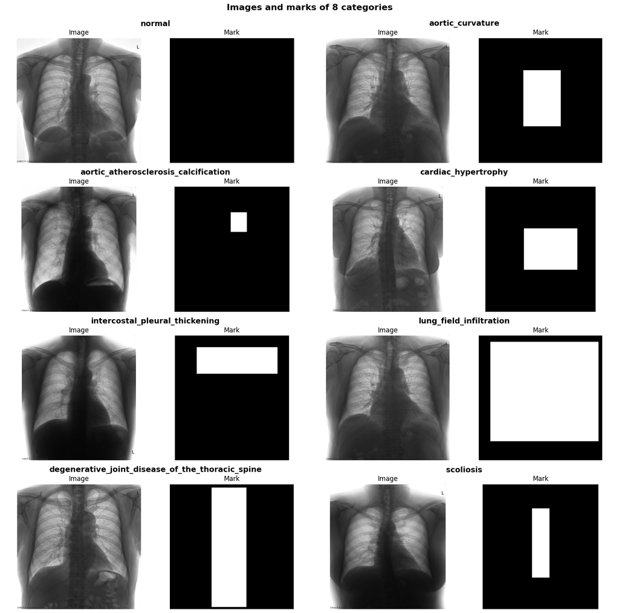

```python
def plot_images_and_marks(df):

    temp = df[df["category"].duplicated() == False]

    rows, cols = 4, 2
    fig = plt.figure(figsize = (16, 16))
    grid = plt.GridSpec(rows, cols)

    for i in range(rows * cols):
        image = pydicom.dcmread(os.path.join(config.root, "train", temp.iloc[i, 5])).pixel_array
        if temp.iloc[i, 1] != "normal":
            mark = np.array(Image.open(os.path.join(config.root, "train", temp.iloc[i, 6])))
        else:
            mark = np.zeros((image.shape[0], image.shape[1]))

        categories = fig.add_subplot(grid[i])
        categories.set_title(f"{temp.iloc[i, 1]}\n", fontweight = 'semibold', size = 14)
        categories.set_axis_off()

        gs = gridspec.GridSpecFromSubplotSpec(1, 2, subplot_spec = grid[i])

        ax = fig.add_subplot(gs[0])
        ax.imshow(image, cmap = "gray")
        ax.set_title("Image")
        ax.axis("off")

        ax = fig.add_subplot(gs[1], sharey = ax)
        ax.imshow(mark, cmap = "gray")
        ax.set_title("Mark")
        ax.axis("off")

    fig.patch.set_facecolor('white')
    fig.suptitle("Images and marks of 8 categories\n", fontweight = 'bold', size = 16)
    fig.tight_layout()

plot_images_and_marks(train_df)
```

# X-ray image normalization

這部分需完成 **intensity log-transformation** 跟 **simplest color balance algorithm** ，目的是為了轉換影像型態及調整 L & R 字樣的亮度。  
以 ID 為 TDR02_20161209_161439 的病患為例，輸出轉換前及轉換後的 X-ray 影像：

```python
def X_ray_normalization(dcm_file, vmin, vmax):

    img = pydicom.dcmread(dcm_file)
    origin = img.pixel_array

    # needed values
    WW = img.WindowWidth
    WC = img.WindowCenter
    BitsStored = img.BitsStored

    # intensity log-transformation
    lower_bound = WC - WW / 2
    upper_bound = WC + WW / 2

    # 限制影像範圍
    clamped_array = np.clip(origin, lower_bound, upper_bound)

    # 對數轉換
    log_img = -np.log((1 + clamped_array) / (2 ** BitsStored))
    # simplest color balance algorithm
    # Linear contrast stretching: Normalize between 0 and 1
    normalize_img = (log_img - vmin) / (vmax-vmin)
    normalize_img = np.clip(normalize_img, 0, 1)

    return origin, log_img, normalize_img
```

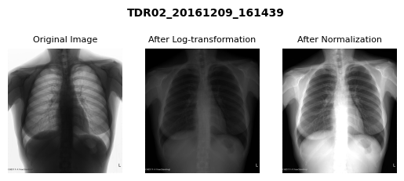

```python
def plot_before_and_after(ID, df):

    patient_df = df[df["ID"] == ID]
    path = os.path.join(config.root, "train", patient_df.iloc[0, 5])
    origin, log_img, normalize_img = X_ray_normalization(path, vmin = 0, vmax = 2.5)

    plt.figure(figsize = (16, 16))
    fig, ax = plt.subplots(1, 3)
    np.vectorize(lambda ax: ax.axis('off'))(ax)
    plt.subplots_adjust(wspace = None, hspace = None)

    ax[0].imshow(origin, cmap = "gray")
    ax[0].set_title("Original Image", size = 8)
    ax[1].imshow(log_img, cmap = "gray")
    ax[1].set_title("After Log-transformation", size = 8)
    ax[2].imshow(normalize_img, cmap = "gray")
    ax[2].set_title("After Normalization", size = 8)

    fig.suptitle(f"{ID}", fontweight = 'bold', size = 10, x = 0.52, y = 0.77)

plot_before_and_after(ID = "TDR02_20161209_161439", df = train_df)
```

# Mask image to bounding box

這部分將資料集中的 mask 轉換為丟入模型所需的 bounding box，並畫出8種類別的轉換後影像、轉換後影像及 bounding box，以及 mask 影像：

```python
def mask_to_bbox(mark_path):
    img = np.array(Image.open(mark_path))

    mask = img != 0
    sk_mask = sk_label(mask, connectivity = 2)
    regions = sk_regions(sk_mask)
    bboxes = []
    for region in regions:
        if region.area < 3000 :
            continue
        bboxes.append(region.bbox)

    ymin, xmin, ymax, xmax = bboxes[0]

    return xmin, ymin, xmax, ymax
```

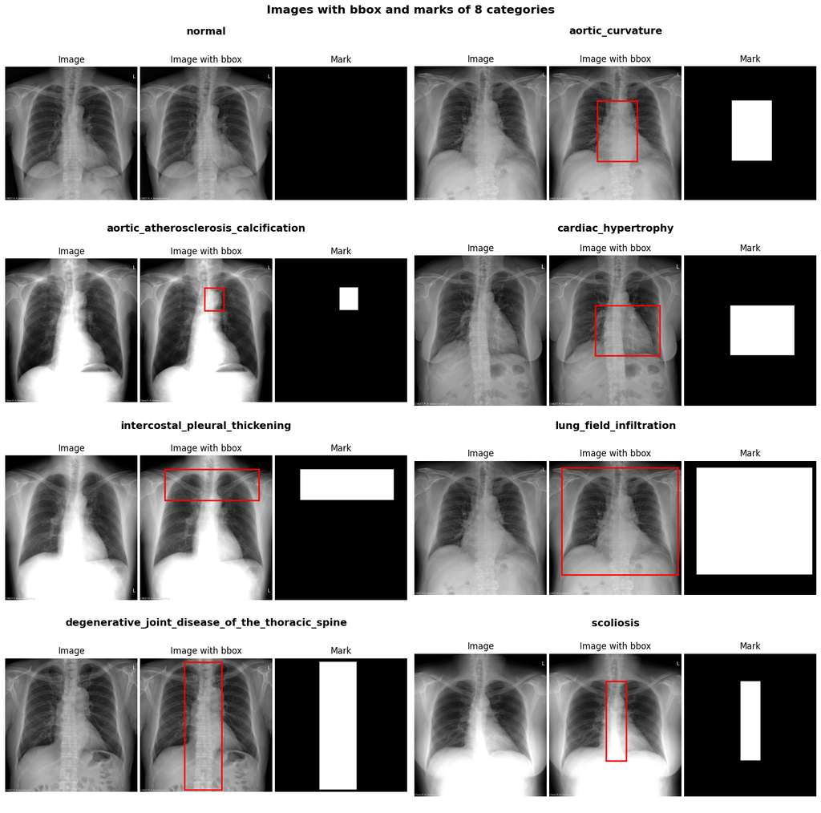

```python
def plot_bbox_and_mark(df):

    temp = df[df["category"].duplicated() == False]

    rows, cols = 4, 2
    fig = plt.figure(figsize = (16, 16))
    grid = plt.GridSpec(rows, cols)

    for i in range(rows * cols):

        path = os.path.join(config.root, "train", temp.iloc[i, 5])
        mark_path = os.path.join(config.root, "train", temp.iloc[i, 6])

        _, _, after = X_ray_normalization(path, vmin = 0, vmax = 2.5)

        if temp.iloc[i, 1] != "normal":
            mark = np.array(Image.open(mark_path))
            xmin, ymin, xmax, ymax = mask_to_bbox(mark_path)
        else:
            mark = np.zeros((after.shape[0], after.shape[1]))
            xmin, ymin, xmax, ymax = 0, 0, 0, 0

        bbox = patches.Rectangle((xmin, ymin), xmax - xmin, ymax - ymin, linewidth = 2,
                                 edgecolor = "r", facecolor = 'none')

        categories = fig.add_subplot(grid[i])
        categories.set_title(f"{temp.iloc[i, 1]}\n", fontweight = 'semibold', size = 14)
        categories.set_axis_off()

        gs = gridspec.GridSpecFromSubplotSpec(1, 3, subplot_spec = grid[i])

        ax = fig.add_subplot(gs[0])
        ax.imshow(after, cmap = "gray")
        ax.set_title("Image")
        ax.axis("off")

        ax = fig.add_subplot(gs[1], sharey = ax)
        ax.imshow(after, cmap = "gray")
        ax.add_patch(bbox)
        ax.set_title("Image with bbox")
        ax.axis("off")

        ax = fig.add_subplot(gs[2], sharey = ax)
        ax.imshow(mark, cmap = "gray")
        ax.set_title("Mark")
        ax.axis("off")

    fig.patch.set_facecolor('white')
    fig.suptitle("Images with bbox and marks of 8 categories\n", fontweight = 'bold', size = 16)
    fig.tight_layout()

plot_bbox_and_mark(train_df)
```

接著將轉換出的 bounding box 寫入 training dataframe 中：

```python
def write_bbox(df):

    all_xmin, all_ymin, all_xmax, all_ymax = [], [], [], []

    for i in range(df.shape[0]):

        if df.iloc[i, 1] != "normal":
            mark_path = os.path.join(config.root, "train", df.iloc[i, 6])
            xmin, ymin, xmax, ymax = mask_to_bbox(mark_path)
        else:
            xmin, ymin, xmax, ymax = 0, 0, 0, 0

        all_xmin.append(xmin)
        all_ymin.append(ymin)
        all_xmax.append(xmax)
        all_ymax.append(ymax)

    df["xmin"] = all_xmin
    df["ymin"] = all_ymin
    df["xmax"] = all_xmax
    df["ymax"] = all_ymax

write_bbox(train_df)
train_df
```

|  | ID | category | Width | Height | Filename | ImagePath | MarkPath | xmin | ymin | xmax | ymax |
| --- | --- | --- | --- | --- | --- | --- | --- | --- | --- | --- | --- |
| 0 | TDR04_20180315_075734 | normal | 2328 | 2344 | 220_97.dcm | normal/image/220_97.dcm | normal/mark/220_97.dcm.jpg | 0 | 0 | 0 | 0 |
| 1 | TDR04_20180315_080518 | normal | 2472 | 2560 | 220_94.dcm | normal/image/220_94.dcm | normal/mark/220_94.dcm.jpg | 0 | 0 | 0 | 0 |
| 2 | TDR04_20180315_081322 | normal | 2312 | 2496 | 220_93.dcm | normal/image/220_93.dcm | normal/mark/220_93.dcm.jpg | 0 | 0 | 0 | 0 |
| 3 | TDR04_20180315_081746 | normal | 2448 | 2584 | 220_92.dcm | normal/image/220_92.dcm | normal/mark/220_92.dcm.jpg | 0 | 0 | 0 | 0 |
| 4 | TDR04_20180315_082113 | normal | 2144 | 2384 | 220_91.dcm | normal/image/220_91.dcm | normal/mark/220_91.dcm.jpg | 0 | 0 | 0 | 0 |
| ... | ... | ... | ... | ... | ... | ... | ... | ... | ... | ... | ... |
| 446 | TDR02_20161209_161439 | scoliosis | 2376 | 2592 | 4440_5.dcm | scoliosis/image/4440_5.dcm | scoliosis/mark/4440_5.dcm.jpg | 1016 | 560 | 1432 | 2328 |
| 447 | TDR04_20180224_084933 | scoliosis | 2248 | 2600 | 4440_0.dcm | scoliosis/image/4440_0.dcm | scoliosis/mark/4440_0.dcm.jpg | 912 | 552 | 1408 | 2272 |
| 448 | TDR04_20180226_082354 | scoliosis | 2488 | 2456 | 4440.dcm | scoliosis/image/4440.dcm | scoliosis/mark/4440.dcm.jpg | 1016 | 464 | 1560 | 2184 |
| 449 | TDR01_20171106_095308 | scoliosis | 2320 | 2376 | A0_29.dcm | scoliosis/image/A0_29.dcm | scoliosis/mark/A0_29.dcm.jpg | 1032 | 512 | 1384 | 2016 |
| 450 | TDR01_20171108_100516 | scoliosis | 2280 | 2288 | A0_28.dcm | scoliosis/image/A0_28.dcm | scoliosis/mark/A0_28.dcm.jpg | 912 | 592 | 1392 | 2120 |

451 rows × 11 columns

# Write class id

因之後轉換資料格式所需，我們需要把疾病類別改寫為 `class_id`，也就是 0 ~ 7 的數字。

```python
labels = list(train_df["category"].unique())
label2class = {l: c for c, l in enumerate(labels)}
label2class
```

```
{'normal': 0,
 'aortic_curvature': 1,
 'aortic_atherosclerosis_calcification': 2,
 'cardiac_hypertrophy': 3,
 'intercostal_pleural_thickening': 4,
 'lung_field_infiltration': 5,
 'degenerative_joint_disease_of_the_thoracic_spine': 6,
 'scoliosis': 7}
```

```python
# write class_id
def write_class_id(df):
    class_id = []
    for i in range(df.shape[0]):
        class_id.append(label2class[df.iloc[i, 1]])
    df["class_id"] = class_id

write_class_id(train_df)
train_df
```

|  | ID | category | Width | Height | Filename | ImagePath | MarkPath | xmin | ymin | xmax | ymax | class_id |
| --- | --- | --- | --- | --- | --- | --- | --- | --- | --- | --- | --- | --- |
| 0 | TDR04_20180315_075734 | normal | 2328 | 2344 | 220_97.dcm | normal/image/220_97.dcm | normal/mark/220_97.dcm.jpg | 0 | 0 | 0 | 0 | 0 |
| 1 | TDR04_20180315_080518 | normal | 2472 | 2560 | 220_94.dcm | normal/image/220_94.dcm | normal/mark/220_94.dcm.jpg | 0 | 0 | 0 | 0 | 0 |
| 2 | TDR04_20180315_081322 | normal | 2312 | 2496 | 220_93.dcm | normal/image/220_93.dcm | normal/mark/220_93.dcm.jpg | 0 | 0 | 0 | 0 | 0 |
| 3 | TDR04_20180315_081746 | normal | 2448 | 2584 | 220_92.dcm | normal/image/220_92.dcm | normal/mark/220_92.dcm.jpg | 0 | 0 | 0 | 0 | 0 |
| 4 | TDR04_20180315_082113 | normal | 2144 | 2384 | 220_91.dcm | normal/image/220_91.dcm | normal/mark/220_91.dcm.jpg | 0 | 0 | 0 | 0 | 0 |
| ... | ... | ... | ... | ... | ... | ... | ... | ... | ... | ... | ... | ... |
| 446 | TDR02_20161209_161439 | scoliosis | 2376 | 2592 | 4440_5.dcm | scoliosis/image/4440_5.dcm | scoliosis/mark/4440_5.dcm.jpg | 1016 | 560 | 1432 | 2328 | 7 |
| 447 | TDR04_20180224_084933 | scoliosis | 2248 | 2600 | 4440_0.dcm | scoliosis/image/4440_0.dcm | scoliosis/mark/4440_0.dcm.jpg | 912 | 552 | 1408 | 2272 | 7 |
| 448 | TDR04_20180226_082354 | scoliosis | 2488 | 2456 | 4440.dcm | scoliosis/image/4440.dcm | scoliosis/mark/4440.dcm.jpg | 1016 | 464 | 1560 | 2184 | 7 |
| 449 | TDR01_20171106_095308 | scoliosis | 2320 | 2376 | A0_29.dcm | scoliosis/image/A0_29.dcm | scoliosis/mark/A0_29.dcm.jpg | 1032 | 512 | 1384 | 2016 | 7 |
| 450 | TDR01_20171108_100516 | scoliosis | 2280 | 2288 | A0_28.dcm | scoliosis/image/A0_28.dcm | scoliosis/mark/A0_28.dcm.jpg | 912 | 592 | 1392 | 2120 | 7 |

451 rows × 12 columns

# Split training set and validation set

這裡要注意的是，由於一張影像可能包含許多類不同疾病 ( multi-label ) ，所以在切分 training set 跟 validation set 時不能用一般的 `train_test_split` ，否則會導致類別不平衡。此外，由於一名病人在 dataframe 中可能有多筆資料，所以分的時候記得要用 ID 去分！

首先把疾病類別改寫為 one-hot encoding 形式：

```python
train_df.nunique()['ID'], train_df.shape[0]
```

```
(348, 451)
```

```python
binarizer = MultiLabelBinarizer()
disease_id = []
for ID in train_df.ID.unique():
    diseases = []
    temp = train_df[train_df["ID"] == ID]
    diseases.extend(list(temp["class_id"]))
    disease_id.append(diseases)

one_hot = binarizer.fit_transform(disease_id)
one_hot
```

```
array([[1, 0, 0, ..., 0, 0, 0],
       [1, 0, 0, ..., 0, 0, 0],
       [1, 0, 0, ..., 0, 0, 0],
       ...,
       [0, 0, 0, ..., 0, 0, 1],
       [0, 0, 0, ..., 0, 0, 1],
       [0, 0, 0, ..., 0, 0, 1]])
```

```python
one_hot.shape
```

```
(348, 8)
```

```python
train_ID, train_label, val_ID, val_label = iterative_train_test_split(np.expand_dims(train_df["ID"].unique(), axis = 1), one_hot, test_size = 0.2)

training = train_df[train_df["ID"].isin(train_ID.ravel())]
validation = train_df[train_df["ID"].isin(val_ID.ravel())]
```

# Dataset to COCO format

https://cocodataset.org/#format-data

大部分 object detection 模型要求丟入的資料格式為 Pascal VOC format 或 COCO format，這裡示範如何將資料轉換為 COCO format。

COCO dataset 包含五個部分，分別是：

- `info` : general information about the dataset
- `licenses` : license information for the images in the dataset
- `images` : a list of images in the dataset
- `annotations` : a list of annotations ( including bounding boxes ) that are present in all images in the dataset
- `categories` : a list of label categories(預設0是background不用設定)

其中 `info` 和 `licenses` 並非必要，所以這裡我們只創建 `images`、`annotations` 和 `categories` 這三部分

```python
categories = []
for l, c in label2class.items():
    if l == "normal":
        continue
    categories.append({"id": c, "name": l})

categories
```

```
[{'id': 1, 'name': 'aortic_curvature'},
 {'id': 2, 'name': 'aortic_atherosclerosis_calcification'},
 {'id': 3, 'name': 'cardiac_hypertrophy'},
 {'id': 4, 'name': 'intercostal_pleural_thickening'},
 {'id': 5, 'name': 'lung_field_infiltration'},
 {'id': 6, 'name': 'degenerative_joint_disease_of_the_thoracic_spine'},
 {'id': 7, 'name': 'scoliosis'}]
```

## Format:

A dictionary containing 3 key items below, an individual item consists of a list of dictionaries

https://www.v7labs.com/blog/coco-dataset-guide

#### **Images**

- **id**
- **file_name**
- **height and width**

#### **Annotations**

- **id**: annotation unique id
- **image_id**: The ID of image(id under **Images**) that this annotation belongs to.
- **category_id**: ID of the object's category.
- **bbox**: Bounding box **[x, y, width, height]**
- **segmentation**: Segmentation polygons for the object.
- **area**: Area of the object (used for filtering).
- **iscrowd**: Flag indicating if the annotation is for a crowd (e.g., a dense cluster of objects).

### Bounding boxes format

[figure not shown]

```python
# change data to coco format
def coco_format(df, categories):
    coco_output = {
        "images" : [],
        "categories" : [],
        "annotations" : []
        }

    coco_output['categories'] = categories

    annotation_id = 0
    for image_id, img_name in enumerate(df.ID.unique()):
        image_df = df[df.ID == img_name]
        if len(image_df) == 1:
            image_dict = {
                "file_name" : list(image_df.category)[0] + "/" + list(image_df.Filename)[0].replace(".dcm", ".jpg"),
                "height" : int(image_df.Height),
                "width" : int(image_df.Width),
                "id" : image_id
                }
        else:
            unique = image_df.iloc[0, :]
            image_dict = {
                "file_name" : unique.category + "/" + unique.Filename.replace(".dcm", ".jpg"),
                "height" : int(unique.Height),
                "width" : int(unique.Width),
                "id" : image_id
                }
        coco_output['images'].append(image_dict)

        for _, row in image_df.iterrows():
            xmin = int(row.xmin)
            ymin = int(row.ymin)
            xmax = int(row.xmax)
            ymax = int(row.ymax)
            if xmin == ymin == xmax == ymax == 0:
                continue

            area = (xmax - xmin) * (ymax - ymin)

            poly = [
                (xmin, ymin), (xmax, ymin),
                (xmax, ymax), (xmin, ymax)
            ]
            poly = list(itertools.chain.from_iterable(poly))

            mask_dict = {
                "id" : annotation_id,
                "image_id" : image_id,
                "category_id" : row.class_id,
                "bbox" : [xmin, ymin, (xmax - xmin), (ymax - ymin)],
                "area" : area,
                "iscrowd" : 0,
                "segmentation" : [poly],
                }
            coco_output["annotations"].append(mask_dict)
            annotation_id += 1

    return coco_output
```

```python
train_coco = coco_format(training, categories)
val_coco = coco_format(validation, categories)
```

```python
train_coco['images'][:5]
```

```
[{'file_name': 'normal/220_94.jpg', 'height': 2560, 'width': 2472, 'id': 0},
 {'file_name': 'normal/220_93.jpg', 'height': 2496, 'width': 2312, 'id': 1},
 {'file_name': 'normal/220_90.jpg', 'height': 2632, 'width': 2320, 'id': 2},
 {'file_name': 'normal/220_88.jpg', 'height': 2624, 'width': 2560, 'id': 3},
 {'file_name': 'normal/220_86.jpg', 'height': 2632, 'width': 2544, 'id': 4}]
```

```python
train_coco['annotations'][:5]
```

```
[{'id': 0,
  'image_id': 64,
  'category_id': 1,
  'bbox': [904, 656, 760, 1143],
  'area': 868680,
  'iscrowd': 0,
  'segmentation': [[904, 656, 1664, 656, 1664, 1799, 904, 1799]]},
 {'id': 1,
  'image_id': 64,
  'category_id': 5,
  'bbox': [232, 128, 2200, 2024],
  'area': 4452800,
  'iscrowd': 0,
  'segmentation': [[232, 128, 2432, 128, 2432, 2152, 232, 2152]]},
 {'id': 2,
  'image_id': 65,
  'category_id': 1,
  'bbox': [872, 736, 632, 1072],
  'area': 677504,
  'iscrowd': 0,
  'segmentation': [[872, 736, 1504, 736, 1504, 1808, 872, 1808]]},
 {'id': 3,
  'image_id': 65,
  'category_id': 5,
  'bbox': [144, 280, 2168, 1952],
  'area': 4231936,
  'iscrowd': 0,
  'segmentation': [[144, 280, 2312, 280, 2312, 2232, 144, 2232]]},
 {'id': 4,
  'image_id': 66,
  'category_id': 1,
  'bbox': [1024, 528, 608, 1040],
  'area': 632320,
  'iscrowd': 0,
  'segmentation': [[1024, 528, 1632, 528, 1632, 1568, 1024, 1568]]}]
```

```python
train_coco['categories']
```

```
[{'id': 1, 'name': 'aortic_curvature'},
 {'id': 2, 'name': 'aortic_atherosclerosis_calcification'},
 {'id': 3, 'name': 'cardiac_hypertrophy'},
 {'id': 4, 'name': 'intercostal_pleural_thickening'},
 {'id': 5, 'name': 'lung_field_infiltration'},
 {'id': 6, 'name': 'degenerative_joint_disease_of_the_thoracic_spine'},
 {'id': 7, 'name': 'scoliosis'}]
```

# Save files

這裡將經過 normalization 處理後的影像存為 .jpg 檔，並將轉換為 COCO format後的資料存為 .json 檔，方便之後使用：

```python
def dcm_to_jpg(df):

    for path in df.ImagePath:
        dcm_path = os.path.join(config.root, "train", path)
        _, _, image = X_ray_normalization(dcm_path, vmin = 0, vmax = 2.5)
        file = os.path.join("/kaggle/working/", path.split("/")[0])
        jpg_name = path.split("/")[-1].replace(".dcm", ".jpg")

        if os.path.isdir(file) == False:
            os.makedirs(file)

        plt.imsave(f"{file}/{jpg_name}", image, cmap = "gray")
```

```python
dcm_to_jpg(train_df)
```

```python
with open("train.json", "w") as outfile:
    json.dump(train_coco, outfile)


with open("val.json", "w") as outfile:
    json.dump(val_coco, outfile)
```

```python
import shutil

# 定義本地與雲端的路徑
local_root = "/kaggle/working/"
cloud_root = "/content/drive/MyDrive/processed_images/"

# 將本地的 JPG 圖片儲存到雲端
def upload_to_cloud(local_root, cloud_root):
    for root, dirs, files in os.walk(local_root):
        for file in files:
            if file.endswith(".jpg"):
                # 取得本地檔案路徑
                local_path = os.path.join(root, file)

                # 建立相對的雲端路徑
                relative_path = os.path.relpath(local_path, local_root)
                cloud_path = os.path.join(cloud_root, relative_path)
                cloud_dir = os.path.dirname(cloud_path)

                # 確保雲端目錄存在
                if not os.path.exists(cloud_dir):
                    os.makedirs(cloud_dir)

                # 複製檔案到雲端
                shutil.copy(local_path, cloud_path)
                print(f"Uploaded {file} to {cloud_path}")

# 執行上傳
upload_to_cloud(local_root, cloud_root)
```

```
Uploaded 4440a.jpg to /content/drive/MyDrive/processed_images/aortic_atherosclerosis_calcification/4440a.jpg
Uploaded 10_1d.jpg to /content/drive/MyDrive/processed_images/aortic_atherosclerosis_calcification/10_1d.jpg
Uploaded 10_2d.jpg to /content/drive/MyDrive/processed_images/aortic_atherosclerosis_calcification/10_2d.jpg
Uploaded 10_8a.jpg to /content/drive/MyDrive/processed_images/aortic_atherosclerosis_calcification/10_8a.jpg
Uploaded 10d.jpg to /content/drive/MyDrive/processed_images/aortic_atherosclerosis_calcification/10d.jpg
Uploaded FILE0_5c.jpg to /content/drive/MyDrive/processed_images/aortic_atherosclerosis_calcification/FILE0_5c.jpg
Uploaded 10_2a.jpg to /content/drive/MyDrive/processed_images/aortic_atherosclerosis_calcification/10_2a.jpg
Uploaded 4440_1a.jpg to /content/drive/MyDrive/processed_images/aortic_atherosclerosis_calcification/4440_1a.jpg
Uploaded 10b.jpg to /content/drive/MyDrive/processed_images/aortic_atherosclerosis_calcification/10b.jpg
Uploaded 4440_3b.jpg to /content/drive/MyDrive/processed_images/aortic_atherosclerosis_calcification/4440_3b.jpg
Uploaded 10_11a.jpg to /content/drive/MyDrive/processed_images/aortic_atherosclerosis_calcification/10_11a.jpg
Uploaded FILE0_7c.jpg to /content/drive/MyDrive/processed_images/aortic_atherosclerosis_calcification/FILE0_7c.jpg
Uploaded 4440_1b.jpg to /content/drive/MyDrive/processed_images/aortic_atherosclerosis_calcification/4440_1b.jpg
Uploaded A0_0d.jpg to /content/drive/MyDrive/processed_images/aortic_atherosclerosis_calcification/A0_0d.jpg
Uploaded 10_0 (2)d.jpg to /content/drive/MyDrive/processed_images/aortic_atherosclerosis_calcification/10_0 (2)d.jpg
Uploaded 10_4d.jpg to /content/drive/MyDrive/processed_images/aortic_atherosclerosis_calcification/10_4d.jpg
Uploaded 4440_0d.jpg to /content/drive/MyDrive/processed_images/aortic_atherosclerosis_calcification/4440_0d.jpg
Uploaded A0d.jpg to /content/drive/MyDrive/processed_images/aortic_atherosclerosis_calcification/A0d.jpg
Uploaded 220_2a.jpg to /content/drive/MyDrive/processed_images/aortic_atherosclerosis_calcification/220_2a.jpg
Uploaded 10_0b.jpg to /content/drive/MyDrive/processed_images/aortic_atherosclerosis_calcification/10_0b.jpg
Uploaded 10_5d.jpg to /content/drive/MyDrive/processed_images/aortic_atherosclerosis_calcification/10_5d.jpg
Uploaded 220 (2)d.jpg to /content/drive/MyDrive/processed_images/aortic_atherosclerosis_calcification/220 (2)d.jpg
Uploaded FILE0_0b.jpg to /content/drive/MyDrive/processed_images/aortic_atherosclerosis_calcification/FILE0_0b.jpg
Uploaded 220a.jpg to /content/drive/MyDrive/processed_images/aortic_atherosclerosis_calcification/220a.jpg
Uploaded FILE0d.jpg to /content/drive/MyDrive/processed_images/aortic_atherosclerosis_calcification/FILE0d.jpg
Uploaded 10 (2)d.jpg to /content/drive/MyDrive/processed_images/aortic_atherosclerosis_calcification/10 (2)d.jpg
Uploaded 10_0a.jpg to /content/drive/MyDrive/processed_images/aortic_atherosclerosis_calcification/10_0a.jpg
Uploaded 10_1 (2)d.jpg to /content/drive/MyDrive/processed_images/aortic_atherosclerosis_calcification/10_1 (2)d.jpg
Uploaded 10_9a.jpg to /content/drive/MyDrive/processed_images/aortic_atherosclerosis_calcification/10_9a.jpg
Uploaded Volume0b.jpg to /content/drive/MyDrive/processed_images/aortic_atherosclerosis_calcification/Volume0b.jpg
Uploaded Volume0_7c.jpg to /content/drive/MyDrive/processed_images/aortic_atherosclerosis_calcification/Volume0_7c.jpg
Uploaded 220_3a.jpg to /content/drive/MyDrive/processed_images/aortic_atherosclerosis_calcification/220_3a.jpg
Uploaded 220_4a.jpg to /content/drive/MyDrive/processed_images/aortic_atherosclerosis_calcification/220_4a.jpg
Uploaded 10_12a.jpg to /content/drive/MyDrive/processed_images/aortic_atherosclerosis_calcification/10_12a.jpg
Uploaded Volume0_11c.jpg to /content/drive/MyDrive/processed_images/aortic_atherosclerosis_calcification/Volume0_11c.jpg
Uploaded 220_0b.jpg to /content/drive/MyDrive/processed_images/aortic_atherosclerosis_calcification/220_0b.jpg
Uploaded 4440_3a.jpg to /content/drive/MyDrive/processed_images/aortic_atherosclerosis_calcification/4440_3a.jpg
Uploaded Volume0_0c.jpg to /content/drive/MyDrive/processed_images/aortic_atherosclerosis_calcification/Volume0_0c.jpg
Uploaded 10_10a.jpg to /content/drive/MyDrive/processed_images/aortic_atherosclerosis_calcification/10_10a.jpg
Uploaded FILE0a.jpg to /content/drive/MyDrive/processed_images/aortic_atherosclerosis_calcification/FILE0a.jpg
```

[output cut: 396 more lines]

```
Uploaded A0_29.jpg to /content/drive/MyDrive/processed_images/scoliosis/A0_29.jpg
Uploaded 10_14.jpg to /content/drive/MyDrive/processed_images/scoliosis/10_14.jpg
Uploaded A0_23.jpg to /content/drive/MyDrive/processed_images/scoliosis/A0_23.jpg
Uploaded A0_12.jpg to /content/drive/MyDrive/processed_images/scoliosis/A0_12.jpg
Uploaded 10_13.jpg to /content/drive/MyDrive/processed_images/scoliosis/10_13.jpg
Uploaded A0_10.jpg to /content/drive/MyDrive/processed_images/scoliosis/A0_10.jpg
Uploaded 220_0 (2).jpg to /content/drive/MyDrive/processed_images/scoliosis/220_0 (2).jpg
Uploaded 4440_5.jpg to /content/drive/MyDrive/processed_images/scoliosis/4440_5.jpg
Uploaded 10_6.jpg to /content/drive/MyDrive/processed_images/scoliosis/10_6.jpg
Uploaded 4440_4.jpg to /content/drive/MyDrive/processed_images/scoliosis/4440_4.jpg
Uploaded 220 (2).jpg to /content/drive/MyDrive/processed_images/scoliosis/220 (2).jpg
Uploaded A0_20.jpg to /content/drive/MyDrive/processed_images/scoliosis/A0_20.jpg
Uploaded 220.jpg to /content/drive/MyDrive/processed_images/scoliosis/220.jpg
Uploaded A0_18.jpg to /content/drive/MyDrive/processed_images/scoliosis/A0_18.jpg
Uploaded 10 (2).jpg to /content/drive/MyDrive/processed_images/scoliosis/10 (2).jpg
```

## **TO DO**:

- Preparing for testing dataset (jpg)

```python
test_df = pd.read_csv("/content/drive/MyDrive/hwk05_data/test.csv")
test_df
```

|  | ID | Width | Height | Filename | ImagePath |
| --- | --- | --- | --- | --- | --- |
| 0 | TDR02_20161123_145314 | 2328 | 2360 | 001.dcm | /image/001.dcm |
| 1 | TDR01_20171106_111727 | 2328 | 2424 | 002.dcm | /image/002.dcm |
| 2 | TDR01_20180510_090210 | 2296 | 2432 | 003.dcm | /image/003.dcm |
| 3 | TDR01_20180511_092549 | 2392 | 2576 | 004.dcm | /image/004.dcm |
| 4 | TDR04_20180316_084316 | 2328 | 2352 | 005.dcm | /image/005.dcm |
| ... | ... | ... | ... | ... | ... |
| 108 | TDR04_20180223_093206 | 2048 | 2480 | 109.dcm | /image/109.dcm |
| 109 | TDR02_20161125_122319 | 2096 | 2296 | 110.dcm | /image/110.dcm |
| 110 | TDR02_20180123_115426 | 2400 | 2544 | 111.dcm | /image/111.dcm |
| 111 | TDR01_20180508_173616 | 1536 | 1824 | 112.dcm | /image/112.dcm |
| 112 | TDR02_20161118_145330 | 2104 | 2456 | 113.dcm | /image/113.dcm |

113 rows × 5 columns

```python
def dcm_to_jpg_test(df):

    for path in df.ImagePath:
        #dcm_path = "/content/drive/MyDrive/hwk05_data/test/image/"
        dcm_path = os.path.join(config.root, "test", path[1:])
        print(dcm_path)
        #dcm_path = os.path.join(config.root, "test", path)
        _, _, image = X_ray_normalization(dcm_path, vmin = 0, vmax = 2.5)
        file = os.path.join("/kaggle/workingTest/", path.split("/")[0])
        jpg_name = path.split("/")[-1].replace(".dcm", ".jpg")

        if os.path.isdir(file) == False:
            os.makedirs(file)

        plt.imsave(f"{file}/{jpg_name}", image, cmap = "gray")
```

```python
dcm_to_jpg_test(test_df)
```

```
/content/drive/MyDrive/hwk05_data/test/image/001.dcm
/content/drive/MyDrive/hwk05_data/test/image/002.dcm
/content/drive/MyDrive/hwk05_data/test/image/003.dcm
/content/drive/MyDrive/hwk05_data/test/image/004.dcm
/content/drive/MyDrive/hwk05_data/test/image/005.dcm
/content/drive/MyDrive/hwk05_data/test/image/006.dcm
/content/drive/MyDrive/hwk05_data/test/image/007.dcm
/content/drive/MyDrive/hwk05_data/test/image/008.dcm
/content/drive/MyDrive/hwk05_data/test/image/009.dcm
/content/drive/MyDrive/hwk05_data/test/image/010.dcm
/content/drive/MyDrive/hwk05_data/test/image/011.dcm
/content/drive/MyDrive/hwk05_data/test/image/012.dcm
/content/drive/MyDrive/hwk05_data/test/image/013.dcm
/content/drive/MyDrive/hwk05_data/test/image/014.dcm
/content/drive/MyDrive/hwk05_data/test/image/015.dcm
/content/drive/MyDrive/hwk05_data/test/image/016.dcm
/content/drive/MyDrive/hwk05_data/test/image/017.dcm
/content/drive/MyDrive/hwk05_data/test/image/018.dcm
/content/drive/MyDrive/hwk05_data/test/image/019.dcm
/content/drive/MyDrive/hwk05_data/test/image/020.dcm
/content/drive/MyDrive/hwk05_data/test/image/021.dcm
/content/drive/MyDrive/hwk05_data/test/image/022.dcm
/content/drive/MyDrive/hwk05_data/test/image/023.dcm
/content/drive/MyDrive/hwk05_data/test/image/024.dcm
/content/drive/MyDrive/hwk05_data/test/image/025.dcm
/content/drive/MyDrive/hwk05_data/test/image/026.dcm
/content/drive/MyDrive/hwk05_data/test/image/027.dcm
/content/drive/MyDrive/hwk05_data/test/image/028.dcm
/content/drive/MyDrive/hwk05_data/test/image/029.dcm
/content/drive/MyDrive/hwk05_data/test/image/030.dcm
/content/drive/MyDrive/hwk05_data/test/image/031.dcm
/content/drive/MyDrive/hwk05_data/test/image/032.dcm
/content/drive/MyDrive/hwk05_data/test/image/033.dcm
/content/drive/MyDrive/hwk05_data/test/image/034.dcm
/content/drive/MyDrive/hwk05_data/test/image/035.dcm
/content/drive/MyDrive/hwk05_data/test/image/036.dcm
/content/drive/MyDrive/hwk05_data/test/image/037.dcm
/content/drive/MyDrive/hwk05_data/test/image/038.dcm
/content/drive/MyDrive/hwk05_data/test/image/039.dcm
/content/drive/MyDrive/hwk05_data/test/image/040.dcm
```

[output cut: 58 more lines]

```
/content/drive/MyDrive/hwk05_data/test/image/099.dcm
/content/drive/MyDrive/hwk05_data/test/image/100.dcm
/content/drive/MyDrive/hwk05_data/test/image/101.dcm
/content/drive/MyDrive/hwk05_data/test/image/102.dcm
/content/drive/MyDrive/hwk05_data/test/image/103.dcm
/content/drive/MyDrive/hwk05_data/test/image/104.dcm
/content/drive/MyDrive/hwk05_data/test/image/105.dcm
/content/drive/MyDrive/hwk05_data/test/image/106.dcm
/content/drive/MyDrive/hwk05_data/test/image/107.dcm
/content/drive/MyDrive/hwk05_data/test/image/108.dcm
/content/drive/MyDrive/hwk05_data/test/image/109.dcm
/content/drive/MyDrive/hwk05_data/test/image/110.dcm
/content/drive/MyDrive/hwk05_data/test/image/111.dcm
/content/drive/MyDrive/hwk05_data/test/image/112.dcm
/content/drive/MyDrive/hwk05_data/test/image/113.dcm
```

```python
import shutil

# 定義本地與雲端的路徑
local_root = "/kaggle/workingTest/"
cloud_root = "/content/drive/MyDrive/processed_images/test"

# 將本地的 JPG 圖片儲存到雲端
def upload_to_cloud(local_root, cloud_root):
    for root, dirs, files in os.walk(local_root):
        for file in files:
            if file.endswith(".jpg"):
                # 取得本地檔案路徑
                local_path = os.path.join(root, file)

                # 建立相對的雲端路徑
                relative_path = os.path.relpath(local_path, local_root)
                cloud_path = os.path.join(cloud_root, relative_path)
                cloud_dir = os.path.dirname(cloud_path)

                # 確保雲端目錄存在
                if not os.path.exists(cloud_dir):
                    os.makedirs(cloud_dir)

                # 複製檔案到雲端
                shutil.copy(local_path, cloud_path)
                print(f"Uploaded {file} to {cloud_path}")

# 執行上傳
upload_to_cloud(local_root, cloud_root)
```

```
Uploaded 089.jpg to /content/drive/MyDrive/processed_images/test/089.jpg
Uploaded 038.jpg to /content/drive/MyDrive/processed_images/test/038.jpg
Uploaded 014.jpg to /content/drive/MyDrive/processed_images/test/014.jpg
Uploaded 052.jpg to /content/drive/MyDrive/processed_images/test/052.jpg
Uploaded 040.jpg to /content/drive/MyDrive/processed_images/test/040.jpg
Uploaded 055.jpg to /content/drive/MyDrive/processed_images/test/055.jpg
Uploaded 042.jpg to /content/drive/MyDrive/processed_images/test/042.jpg
Uploaded 061.jpg to /content/drive/MyDrive/processed_images/test/061.jpg
Uploaded 091.jpg to /content/drive/MyDrive/processed_images/test/091.jpg
Uploaded 113.jpg to /content/drive/MyDrive/processed_images/test/113.jpg
Uploaded 109.jpg to /content/drive/MyDrive/processed_images/test/109.jpg
Uploaded 096.jpg to /content/drive/MyDrive/processed_images/test/096.jpg
Uploaded 021.jpg to /content/drive/MyDrive/processed_images/test/021.jpg
Uploaded 062.jpg to /content/drive/MyDrive/processed_images/test/062.jpg
Uploaded 005.jpg to /content/drive/MyDrive/processed_images/test/005.jpg
Uploaded 102.jpg to /content/drive/MyDrive/processed_images/test/102.jpg
Uploaded 025.jpg to /content/drive/MyDrive/processed_images/test/025.jpg
Uploaded 058.jpg to /content/drive/MyDrive/processed_images/test/058.jpg
Uploaded 095.jpg to /content/drive/MyDrive/processed_images/test/095.jpg
Uploaded 045.jpg to /content/drive/MyDrive/processed_images/test/045.jpg
Uploaded 082.jpg to /content/drive/MyDrive/processed_images/test/082.jpg
Uploaded 044.jpg to /content/drive/MyDrive/processed_images/test/044.jpg
Uploaded 043.jpg to /content/drive/MyDrive/processed_images/test/043.jpg
Uploaded 107.jpg to /content/drive/MyDrive/processed_images/test/107.jpg
Uploaded 100.jpg to /content/drive/MyDrive/processed_images/test/100.jpg
Uploaded 046.jpg to /content/drive/MyDrive/processed_images/test/046.jpg
Uploaded 056.jpg to /content/drive/MyDrive/processed_images/test/056.jpg
Uploaded 013.jpg to /content/drive/MyDrive/processed_images/test/013.jpg
Uploaded 068.jpg to /content/drive/MyDrive/processed_images/test/068.jpg
Uploaded 078.jpg to /content/drive/MyDrive/processed_images/test/078.jpg
Uploaded 077.jpg to /content/drive/MyDrive/processed_images/test/077.jpg
Uploaded 032.jpg to /content/drive/MyDrive/processed_images/test/032.jpg
Uploaded 017.jpg to /content/drive/MyDrive/processed_images/test/017.jpg
Uploaded 028.jpg to /content/drive/MyDrive/processed_images/test/028.jpg
Uploaded 049.jpg to /content/drive/MyDrive/processed_images/test/049.jpg
Uploaded 003.jpg to /content/drive/MyDrive/processed_images/test/003.jpg
Uploaded 111.jpg to /content/drive/MyDrive/processed_images/test/111.jpg
Uploaded 026.jpg to /content/drive/MyDrive/processed_images/test/026.jpg
Uploaded 064.jpg to /content/drive/MyDrive/processed_images/test/064.jpg
Uploaded 072.jpg to /content/drive/MyDrive/processed_images/test/072.jpg
```

[output cut: 58 more lines]

```
Uploaded 087.jpg to /content/drive/MyDrive/processed_images/test/087.jpg
Uploaded 024.jpg to /content/drive/MyDrive/processed_images/test/024.jpg
Uploaded 051.jpg to /content/drive/MyDrive/processed_images/test/051.jpg
Uploaded 090.jpg to /content/drive/MyDrive/processed_images/test/090.jpg
Uploaded 073.jpg to /content/drive/MyDrive/processed_images/test/073.jpg
Uploaded 002.jpg to /content/drive/MyDrive/processed_images/test/002.jpg
Uploaded 019.jpg to /content/drive/MyDrive/processed_images/test/019.jpg
Uploaded 011.jpg to /content/drive/MyDrive/processed_images/test/011.jpg
Uploaded 101.jpg to /content/drive/MyDrive/processed_images/test/101.jpg
Uploaded 106.jpg to /content/drive/MyDrive/processed_images/test/106.jpg
Uploaded 081.jpg to /content/drive/MyDrive/processed_images/test/081.jpg
Uploaded 007.jpg to /content/drive/MyDrive/processed_images/test/007.jpg
Uploaded 004.jpg to /content/drive/MyDrive/processed_images/test/004.jpg
Uploaded 031.jpg to /content/drive/MyDrive/processed_images/test/031.jpg
Uploaded 086.jpg to /content/drive/MyDrive/processed_images/test/086.jpg
```